# Bronze Age mounds - Are they different?

Adela Sobotkova

2022-11-17

This script summarizes environmental information on the Bronze Age burial mounds in the Yambol Province, and plots their location and pinpoints other mounds within Yambol that share similar environmental properties.

## Load 2009-2022 mound data

We have a total of 1090 mounds, extinct and uncertain mound features in Yambol.

```r
# Yambol mounds
Yam_mnds <- readRDS("../output_data/Yam_mnds.rds") # dataset is most recent from 27/12/2022
Y_region <- st_read("../data/YamRegion.shp")
head(Yam_mnds)
```

```
## Simple feature collection with 6 features and 18 fields
## Geometry type: POINT
## Dimension:     XY
## Bounding box:  xmin: 452997 ymin: 4706447 xmax: 454596 ymax: 4707823
## Projected CRS: WGS 84 / UTM zone 35N
## # A tibble: 6 × 19
##    TRAP Source      Type  LU_Ar…¹ LU_Top Diame…² Heigh…³ Condi…⁴ Princ…⁵ distB…⁶
##   <dbl> <chr>       <chr> <chr>   <chr>    <dbl>   <dbl> <fct>   <chr>       [m]
## 1  9411 Survey      Buri… Scrub   Scrub       15     1.5 2       Nodata   61029.
## 2  9416 Legacy ver… Buri… Annual… Annua…      20     2   3       Agricu…  62183.
## 3  9417 Legacy ver… Buri… Pasture Pastu…      15     2   4       Looting  62265.
## 4  9409 Legacy ver… Buri… Annual… Pastu…      30     2   2       Agricu…  61453.
## 5  9314 Legacy ver… Buri… Pasture Pastu…      30     2   5       Looting  60783.
## 6  9315 Legacy ver… Buri… Pasture Pastu…      20     1   2       Looting  60718.
## # … with 9 more variables: distTown [m], elevAster <dbl>, slopeAster <dbl>,
## #   aspectAster <dbl>, prom250mbuff <dbl>, TPI <dbl>, TRI <dbl>, rough <dbl>,
## #   geometry <POINT [m]>, and abbreviated variable names ¹LU_Around,
## #   ²DiameterMax, ³HeightMax, ⁴Condition, ⁵PrincipalSourceOfImpact, ⁶distBG[,1]
```

```r
Yam_mnds %>% group_by(Type) %>% tally()
```

```
## Simple feature collection with 3 features and 2 fields
## Geometry type: MULTIPOINT
## Dimension:     XY
## Bounding box:  xmin: 433010.4 ymin: 4647591 xmax: 499612.3 ymax: 4722135
## Projected CRS: WGS 84 / UTM zone 35N
## # A tibble: 3 × 3
##   Type                     n                                            geometry
##   <chr>                <int>                                    <MULTIPOINT [m]>
## 1 Burial Mound           877 ((433010.4 4694365), (433295.2 4693180), (433954.3…
## 2 Extinct Burial Mound   157 ((433034.9 4693186), (433441.6 4692413), (435565.5…
## 3 Uncertain Mound         56 ((436469.5 4693715), (436534.4 4693640), (436657.4…
```

## Extract excavated Bronze Age mounds

We separate out the excavated mounds with Bronze Age (BA) cultural material. First, we filter mounds on the basis of TRAP ID list supplied by Todor and second, we create spatial data for mounds excavated before TRAP survey.

```r
# Filter out the BA mounds from the FAIMS data
bronze <- c(6009,8007,6003,8345,8346,8357,8502) # Toshko provided these TRAP numbers
# He also suspects 8351, 9257, but let's run without them for now.
BA <- Yam_mnds %>%
  filter(TRAP %in% bronze)

# Add literature dimensions to mound 8345, which was excavated before survey
BA$DiameterMax[4] <- 37.5
BA$HeightMax[4] <- 3.2
```

Originally we had 6010 among the BA mound IDs, but visual inspection of pictures did not indicate an excavated. I tested mound 6011 instead of 6010, because the image for 6011 shows an excavated mound and I thought maybe an error happened, but its prominence was less than 6% as it sits on a flat ridge and Todor explained that the mound was half-excavated after survey (2012), for which there is a clear candidate in 6003 (Lozyanska - UTM 35 T 468101 4679119)

The mounds excavated mounds before survey were specified in the AKB and their data and coordinates follow below:

```r
# Add the few mounds excavated before TRAP coverage >> these can also be pulled out of the AOR dataset
extras <- data.frame(place = c("Drazhevo",
                           "Straldzha",
                           "Popovo"),
                 Easting=c(455442,479522,479391),
                 Northing=c(4710935,4715730,4668279),
                 HeightMax=c(2.7,4.0,6.8),
                 DiameterMax = c(37,50,48),
                 LU_Around = c("Pasture","Perennial","Perennial"),
                 Type = c("Burial Mound","Burial Mound","Burial Mound"),
                 Source = c("Excavation","Excavation","Excavation"))
extrasf <- st_as_sf(extras, coords =c("Easting", "Northing"), crs = 32635)
```

Combine the excavated and survey data

```r
# Combine both BA datasets and spatialize
BApoints <- rbind.fill(BA, extrasf) # combine the attributes by row
BAcoords <- rbind(st_coordinates(BA) ,st_coordinates(extrasf)) # combine coordinates
BApoints <- cbind(BApoints, BAcoords) # add coordinate column to the attributes
BApoints <- st_as_sf(BApoints, coords = c("X", "Y"), crs = 32635) # convert to a simple feature
```

## Map the mounds

Compare the excavated Bronze Age mound locations with the other Yambol mounds

```r
library(mapview)
mapview(BApoints) + mapview(Yam_mnds, cex = 2, zcol = "Type")
```

[interactive chart not shown]

```r
#mapview(extrasf) + mapview(Yam_mnds, cex = 2, zcol = "Type")
```

```r
#tiff("../figures/Figure01.tiff", height = 1600, width = 1000)
plot(Y_region$geometry)
     #main = "Excavated Bronze Age mounds (red circles) \n and other mound locations in Yambol")
plot(Yam_mnds$geometry, add = T, col = "lightgrey");
plot(BApoints$geometry, pch = 16, col = "red", add =T)
#dev.off()
```

[output not shown]

## Extract prominence and elevation data from raster

Location alone does not tell us much about the mounds. Let’s extract additional values from the underlying 30m res ASTER imagery so we can compare the mounds’ location formally.

We first load the ASTER layer and a derived slope and aspect raster.

```r
Y_elev <- raster("../output_data/large/Yelev32635.tif")
Y_aspslope <- brick("../output_data/large/Yaspslope.tif")
Y_tri <- brick("../output_data/large/YflowroughTRI.tif") # see script 00 line 380, TRI is the layer no.4 in the sequence of brick(Y_flow, Y_rough, Y_TPI, Y_TRI)
```

Next, we extract values from raster at mound locations.

An alternative to extraction is to, when grabbing the excavated mounds, get the information from the AOR reports, so as to have as complete a record of the morphology as possible. Here I enrich the BA mound data with environmental information extracted from ASTER raster. I simply overwrite the data where it exists so as to be consistent

```r
# Sample elevations at mound locations
BApoints$elevAster <- raster::extract(Y_elev, st_coordinates(BApoints))

# Extract values from slope/aspect rasters created in script 00
BApoints$slopeAster <-  raster::extract(Y_aspslope$Yaspslope.1, st_coordinates(BApoints))

BApoints$aspectAster <-  raster::extract(Y_aspslope$Yaspslope.2, st_coordinates(BApoints))

BApoints$TRI <- raster::extract(Y_tri$YflowroughTRI.4, st_coordinates(BApoints))

BApoints$TPI <- raster::extract(Y_tri$YflowroughTRI.3, st_coordinates(BApoints))

BApoints$rough <- raster::extract(Y_tri$YflowroughTRI.2, st_coordinates(BApoints))

# Calculate prominence

library(FSA) # we need an additional library for the perc() function
     # check the fce is here
BApoints$prom250mbuff <- raster::extract(Y_elev,# raster containing elevation data
                        st_coordinates(BApoints), # centroids of mounds
                        buffer = 250, # actual buffer size in crs units, in this case 250m  or ca 22x22 cells around kernel
                        fun = function(x){perc(x,x[length(x)/2],"lt", na.rm = FALSE, digits = 2)})
```

## Plot BA mounds with the prominence

In the next chunk we view the relative visual control of the surrounding terrain (prominence measures the percentage of area visible from mound within 360 degrees and 250m radius around the mound), and the accessibility. TRI is topographic ruggedness representing another measure of relative elevation above the terrain (it is only present in survey mounds and needs to be calculated for all excavated mounds)

```r
library(leafsync)
```

```r
pr <- mapview(BApoints, zcol ="prom250mbuff")
tri <- mapview(BApoints, zcol = "TRI")
sync(pr, tri)
```

[interactive chart not shown]

## Tabulate and summarize the Bronze Age mound attributes

Let us now look at some attributes of interest such as morphology, elevation, slope, etc.

```r
library(formattable)
highlight <- color_tile("yellow","yellow")

formattable(BApoints %>%
  st_drop_geometry() %>%
  dplyr::select(TRAP, HeightMax, DiameterMax, elevAster, slopeAster, prom250mbuff, LU_Around, LU_Top, TPI, rough), list(
  area(col = 6, row = 3 ) ~ highlight,
  area(col = 6, row = 6 ) ~ highlight,
  area(col = 1, row = 3 ) ~ highlight,
  area(col = 1, row = 6 ) ~ highlight,
  area(col = 6, row = 9 ) ~ highlight,
  area(col = 1, row = 9) ~ highlight
  ))
```

|  | TRAP | HeightMax | DiameterMax | elevAster | slopeAster | prom250mbuff | LU_Around | LU_Top | TPI | rough |
| --- | --- | --- | --- | --- | --- | --- | --- | --- | --- | --- |
| X1 | 8007 | 4.5 | 15.0 | 211.4289 | 4.1581354 | 96.77 | Pasture | Pasture | 0.66615105 | 5.214966 |
| X2 | 6009 | 1.5 | 22.0 | 202.5368 | 6.3925829 | 66.42 | Scrub | Scrub | 0.58851433 | 7.738449 |
| X3 | 6003 | 6.0 | 63.0 | 162.7948 | 5.1050153 | 51.61 | Scrub | Scrub | 0.07163429 | 6.665894 |
| X4 | 8345 | 3.2 | 37.5 | 173.6934 | 5.3060594 | 62.23 | Other | Other | 0.46026993 | 6.057617 |
| X5 | 8346 | 1.0 | 21.0 | 167.3124 | 4.3606491 | 95.29 | Pasture | Pasture | 0.13459969 | 5.737717 |
| X6 | 8357 | 3.0 | 32.0 | 185.0000 | 0.8043471 | 51.45 | Pasture | Pasture | 0.29883194 | 1.210205 |
| X7 | 8502 | 4.0 | 45.0 | 175.2958 | 2.3026028 | 81.95 | Pasture | Pasture | 0.12107658 | 3.237518 |
| X1.1 | NA | 2.7 | 37.0 | 144.9163 | 4.3904009 | 75.72 | Pasture | NA | 0.50815964 | 5.738190 |
| X2.1 | NA | 4.0 | 50.0 | 155.1873 | 3.9191713 | 43.73 | Perennial | NA | 1.54764366 | 6.454422 |
| X3.1 | NA | 6.8 | 48.0 | 217.1393 | 3.0883641 | 79.78 | Perennial | NA | 0.38897896 | 4.578491 |

We might as well summarize these values to get an idea of the range present in BA mounds

```r
summary(BApoints[,c(6:7,12:18)])
```

```
##   DiameterMax      HeightMax       elevAster       slopeAster
##  Min.   :15.00   Min.   :1.000   Min.   :144.9   Min.   :0.8043
##  1st Qu.:24.50   1st Qu.:2.775   1st Qu.:163.9   1st Qu.:3.2961
##  Median :37.25   Median :3.600   Median :174.5   Median :4.2594
##  Mean   :37.05   Mean   :3.670   Mean   :179.5   Mean   :3.9827
##  3rd Qu.:47.25   3rd Qu.:4.375   3rd Qu.:198.2   3rd Qu.:4.9264
##  Max.   :63.00   Max.   :6.800   Max.   :217.1   Max.   :6.3926
##   aspectAster      prom250mbuff        TPI               TRI
##  Min.   : 21.73   Min.   :43.73   Min.   :0.07163   Min.   :0.2988
##  1st Qu.:205.38   1st Qu.:54.27   1st Qu.:0.17566   1st Qu.:1.3172
##  Median :225.30   Median :71.07   Median :0.42462   Median :1.7784
##  Mean   :227.69   Mean   :70.50   Mean   :0.47859   Mean   :1.6765
##  3rd Qu.:334.62   3rd Qu.:81.41   3rd Qu.:0.56843   3rd Qu.:2.1016
##  Max.   :351.80   Max.   :96.77   Max.   :1.54764   Max.   :2.6350
##      rough                geometry
##  Min.   :1.210   POINT        :10
##  1st Qu.:4.738   epsg:32635   : 0
##  Median :5.738   +proj=utm ...: 0
##  Mean   :5.263
##  3rd Qu.:6.355
##  Max.   :7.738
```

An average Bronze Age mound has the height of 3.5 m, diameter around 35 m, the prominence mean of 70%, TRI is around 1.6 and roughness at 5. We may be able to extend these findings to the other Yambol mounds.

Most mounds are located in pastures(5) or rock outcrops with sparse grass cover, some scrub(2) and occasionally vineyards(2) .

```r
BApoints %>%
  st_drop_geometry() %>%
  group_by(LU_Around) %>%
  tally() %>%
  arrange(desc(n))
```

```
## # A tibble: 4 × 2
##   LU_Around     n
##   <chr>     <int>
## 1 Pasture       5
## 2 Perennial     2
## 3 Scrub         2
## 4 Other         1
```

```r
BApoints %>%
  st_drop_geometry() %>%
  group_by(LU_Top) %>%
  tally() %>%
  arrange(desc(n))
```

```
## # A tibble: 4 × 2
##   LU_Top      n
##   <chr>   <int>
## 1 Pasture     4
## 2 <NA>        3
## 3 Scrub       2
## 4 Other       1
```

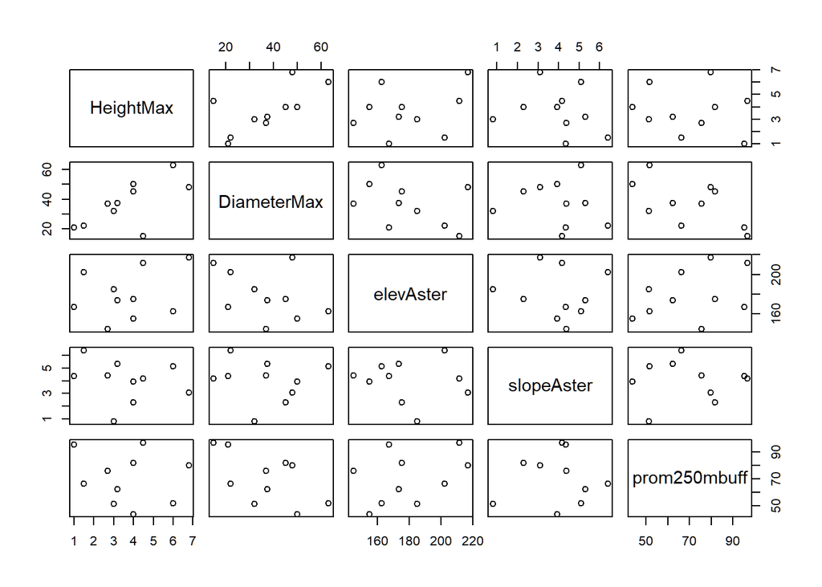

```r
plot(BApoints %>%
       st_drop_geometry() %>%
       dplyr::select(HeightMax, DiameterMax, elevAster, slopeAster, prom250mbuff))
```

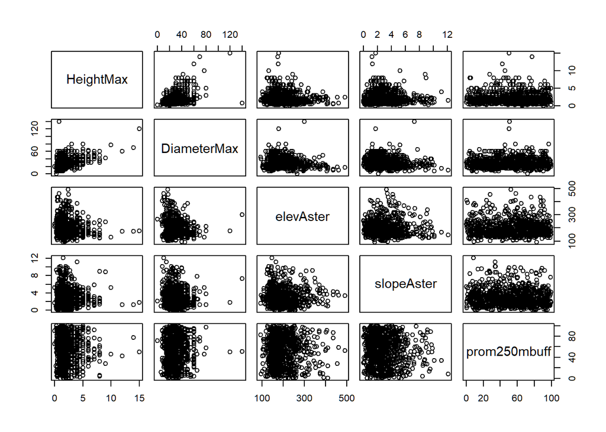

```r
plot(Yam_mnds %>%
       st_drop_geometry() %>%
       filter(Type == "Burial Mound") %>%
       dplyr::select(HeightMax, DiameterMax, elevAster, slopeAster, prom250mbuff))
```

Most of the mounds are in areas of high natural prominence, one exception confirms the rule: Straldzha mound is in a largely flat area of a Pleistocene lake with prominence below 50%. The low score may be caused by the coarse resolution of the 30m ASTER image, the 250m radius (disadvantages mounds located on elevated platforms). The other option is that the mound-builders cared less about elevated location, and sought dissociation from mounds on outcrops (already standing), or hoped to imbue the mound with prominence by raising its height.

## Predict mounds on the basis of prominence and TRI

The mean and median prominence values for BA mounds can provide a guide for other potentially Bronze Age mounds (if we choose a single factor) The following map will show the mounds within the Yambol dataset that have prominence higher than the mean of 70% (265 features) and whose topographic ruggedness is over the mean of 1.6 (52). The lighter the point color the higher their prominence and the more probable their Bronze Age origin

```r
library(mapview)
library(leafsync)

potentialBA <- Yam_mnds %>%
  dplyr::filter(prom250mbuff > 70 & Type == "Burial Mound" & TRI >1.6) %>%
  mapview(zcol = "prom250mbuff")

prom70 <- Yam_mnds %>%
  filter(prom250mbuff > 70 & Type == "Burial Mound") %>%
  mapview(zcol = "prom250mbuff")

BA <- mapview(BApoints)

sync( BA, potentialBA,prom70,ncol=3)
```

[interactive chart not shown]

## With height

Setting the height to 3+ m produces an interesting result. Over 3 m high and 70%+ prominence results in 52 features, same as without the height constraint, but they are in different locations from the 52 features selected on the basis of prominence and TRI. Compare the former (tri-based) features with height-based ones in pane 2 and 3.

```r
library(mapview)
library(leafsync)

potentialBA3m <- Yam_mnds %>%
  filter(HeightMax > 3 &
        # elevAster > 170 &
        # DiameterMax > 30 &&
        # LU_Around == "Scrub" | LU_Around == "Pasture" &&
        #   LU_Top == "Pasture" | LU_Top == "Scrub" &&
         prom250mbuff > 70 &
        # TRI > 1.6 &&
         Type == "Burial Mound" ) %>%
          mapview()

BA <- mapview(BApoints)
sync(BA,potentialBA,potentialBA3m, ncol=3)
```

[interactive chart not shown]

### Tmap Merged Potential BA mounds (3m and TRI >1.6)

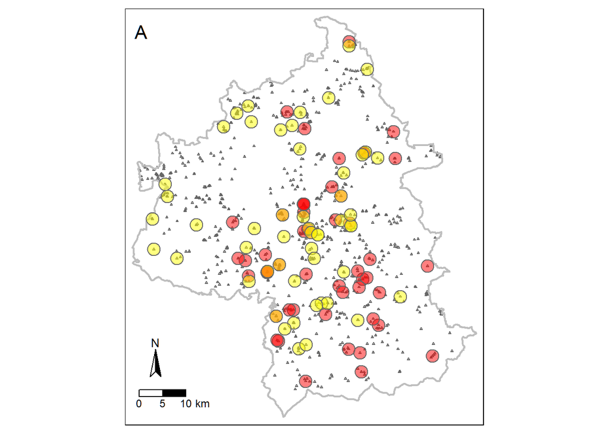

```r
library(tmap)
potentialBA <- Yam_mnds %>%
  filter(TRI > 1.6 &
         prom250mbuff > 70 &
         Type == "Burial Mound" )

potentialBA3m <- Yam_mnds %>%
  filter(HeightMax > 3 &
         prom250mbuff > 70 &
         Type == "Burial Mound" )

tm_shape(Yam_mnds, bbox = st_bbox(Y_region))+
  tm_symbols(shape = 2, col="#666666", size = 0.02) +
tm_shape(Y_region) +
 tm_borders(col = "grey",
              lwd = 2)+
tm_shape(potentialBA, bbox = st_bbox(Y_region)) +
  # tm_polygons(col="cornsilk2", border.alpha = 0)+
  # tm_shape(features) +
  tm_symbols(shape = 21, col="red",
            # size = 0.1,
             alpha = 0.5) +  #6 and 26 are downward triangles
tm_shape(potentialBA3m, bbox = st_bbox(Y_region)) +
  # tm_polygons(col="cornsilk2", border.alpha = 0)+
  # tm_shape(features) +
  tm_symbols(shape = 21, col="yellow",
             #size = 0.1,
             alpha = 0.5) +  #6 and 26 are downward triangles
  tm_compass(type = "arrow",
             position = c("left", "bottom")) +
  tm_scale_bar(position = c("left", "bottom"),
               breaks = c(0,5,10),
               text.size = 0.75) +
  #tm_credits("Sobotkova 2020", position = c("right", "bottom"), size = 0.8) +
  #tm_layout(title = "Registered standing features")
  tm_layout(title = "A")
```

### Tmap Merged Potential BA mounds (3m and TRI >1.6)

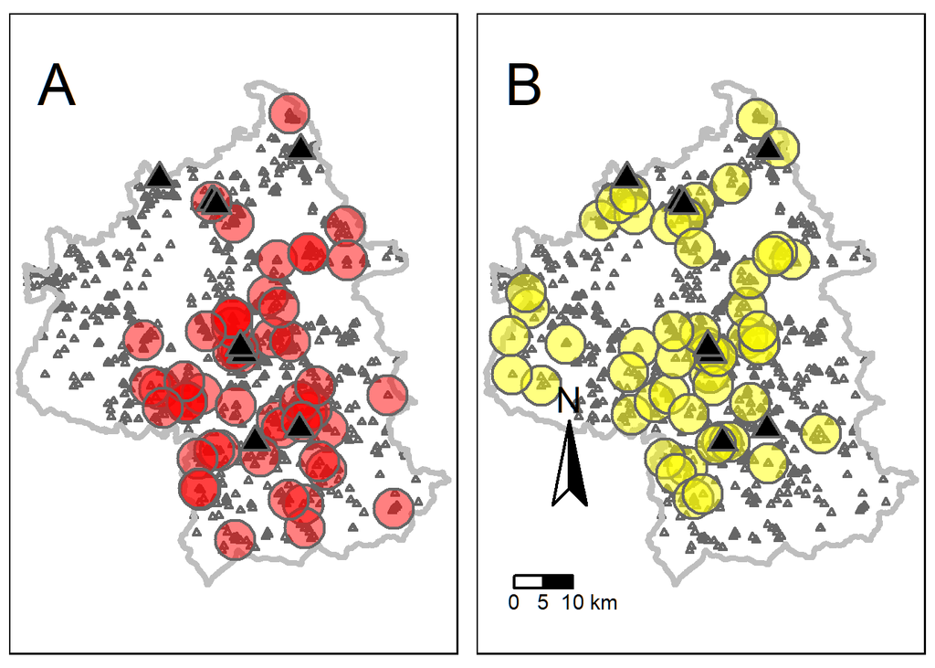

```r
library(tmap)

potentialBA <- Yam_mnds %>%
  filter(TRI > 1.6 &
         prom250mbuff > 70 &
         Type == "Burial Mound" )

potentialBA3m <- Yam_mnds %>%
  filter(HeightMax > 3 &
         prom250mbuff > 70 &
         Type == "Burial Mound" )

tm_3m <- tm_shape(Yam_mnds, bbox = st_bbox(Y_region))+
  tm_symbols(shape = 2, col="#666666", size = 0.02) +
tm_shape(Y_region) +
 tm_borders(col = "grey",
              lwd = 2)+
tm_shape(potentialBA, bbox = st_bbox(Y_region)) +
  tm_symbols(shape = 21, col="red",  #6 and 26 are downward triangles
            # size = 0.1,
             alpha = 0.5)+
  tm_shape(BApoints) +
  tm_symbols(shape = 24, col="black",  #6 and 26 are downward triangles
             size = 0.3)+
 tm_layout(scale =2, title = "A")

tm_tri <- tm_shape(Yam_mnds, bbox = st_bbox(Y_region))+
  tm_symbols(shape = 2, col="#666666", size = 0.02) +
 tm_shape(Y_region) +
    tm_borders(col = "grey",
              lwd = 2)+
 tm_shape(potentialBA3m, bbox = st_bbox(Y_region)) +
  tm_symbols(shape = 21, col="yellow",
             #size = 0.1,
             alpha = 0.5) +  #6 and 26 are downward triangles
 tm_shape(BApoints) +
  tm_symbols(shape = 24, col="black",  #6 and 26 are downward triangles
             size = 0.3)+
  tm_compass(type = "arrow",
             position = c("left", "bottom")) +
  tm_scale_bar(position = c("left", "bottom"),
               breaks = c(0,5,10),
               text.size = 0.75) +
  #tm_credits("Sobotkova 2020", position = c("right", "bottom"), size = 0.8) +
  #tm_layout(title = "Registered standing features")
  tm_layout(scale =2, title = "B")

tmap_arrange(tm_3m, tm_tri)
```

```r
tiff("../figures/Figure04.tiff", width = 1600, height = 1000)
tmap_arrange(tm_3m, tm_tri)
dev.off()
```

## Table the potential BA mounds

```r
potentialBA3m <- Yam_mnds %>%
              st_drop_geometry() %>%
  filter(HeightMax > 3 &
           prom250mbuff > 70 &
         Type == "Burial Mound" )
#write.csv(potentialBA3m, "../output_data/potentialBA3m.csv")

formattable(potentialBA3m)
```

| TRAP | Source | Type | LU_Around | LU_Top | DiameterMax | HeightMax | Condition | PrincipalSourceOfImpact | distBG | distTown | elevAster | slopeAster | aspectAster | prom250mbuff | TPI | TRI | rough |
| --- | --- | --- | --- | --- | --- | --- | --- | --- | --- | --- | --- | --- | --- | --- | --- | --- | --- |
| 9073 | Legacy verification | Burial Mound | Pasture | Scrub | 40 | 4.0 | 4 | Looting | 51008.464 [m] | 135.37613 [m] | 216.7866 | 2.4253145 | 211.45217 | 88.00 | -0.06989861 | 0.9759274 | 3.3631439 |
| 9175 | Legacy verification | Burial Mound | Annual agriculture | Scrub | 40 | 5.0 | 1 | Agriculture | 59003.618 [m] | 74.53215 [m] | 198.2431 | 4.6800186 | 87.95989 | 96.03 | -0.41681290 | 1.5211563 | 4.8863525 |
| 9181 | Legacy verification | Burial Mound | Pasture | Scrub | 60 | 4.0 | 2 | Anthropogenic | 58470.395 [m] | 142.69967 [m] | 150.0426 | 2.9671598 | 131.83792 | 73.09 | 0.13465500 | 1.0969276 | 3.8802338 |
| 9216 | Legacy verification | Burial Mound | Annual agriculture | Pasture | 49 | 5.0 | 2 | Looting | 59302.758 [m] | 959.39600 [m] | 162.6733 | 2.5740781 | 187.05145 | 77.78 | 0.10925674 | 1.0270500 | 2.9966431 |
| 9281 | Legacy verification | Burial Mound | Pasture | Pasture | 40 | 4.0 | 2 | Looting | 58686.223 [m] | 938.46435 [m] | 130.3298 | 3.6580382 | 18.71572 | 77.09 | -0.03388596 | 1.5156136 | 4.5293732 |
| 9332 | Legacy verification | Burial Mound | Pasture | Pasture | 40 | 4.0 | 5 | Looting | 39574.554 [m] | 620.19648 [m] | 243.5981 | 1.8420840 | 283.58454 | 84.06 | 0.49606323 | 0.6540527 | 2.1214752 |
| 9064 | Legacy verification | Burial Mound | Annual agriculture | Pasture | 60 | 6.0 | 5 | Looting | 36233.814 [m] | 1993.02241 [m] | 173.1996 | 1.3251816 | 130.76527 | 87.50 | -0.05104065 | 0.4349060 | 1.6945190 |
| 9247 | Legacy verification | Burial Mound | Pasture | Scrub | 35 | 4.0 | 2 | Looting | 33073.626 [m] | 2080.62520 [m] | 163.2462 | 3.1745961 | 222.01107 | 78.26 | 0.32153511 | 1.2011967 | 3.8739777 |
| 9139 | Legacy verification | Burial Mound | Pasture | Pasture | 50 | 7.0 | 5 | Looting | 26289.064 [m] | 97.64833 [m] | 132.2944 | 2.7756370 | 102.67604 | 92.39 | 1.08477211 | 1.3078213 | 3.6121979 |
| 9446 | Legacy verification | Burial Mound | Annual agriculture | Scrub | 40 | 5.0 | 2 | Looting | 26643.315 [m] | 2928.09891 [m] | 171.9452 | 5.2345184 | 61.81816 | 94.60 | 1.34037971 | 2.2626133 | 6.3942719 |
| 9201 | Legacy verification | Burial Mound | Annual agriculture | Pasture | 40 | 5.0 | 2 | Looting | 55824.158 [m] | 1472.56114 [m] | 164.1649 | 2.6762814 | 244.68078 | 95.27 | 0.27585220 | 0.9831772 | 3.1708984 |
| 9203 | Legacy verification | Burial Mound | Pasture | Perennial agriculture | 50 | 6.0 | 5 | Looting | 56582.849 [m] | 1402.78350 [m] | 201.0560 | 3.3561890 | 258.65461 | 75.45 | -0.09194946 | 1.0824356 | 3.9971924 |
| 8004 | survey | Burial Mound | Scrub | Pasture | 46 | 7.0 | 1 | Post-depositional | 34456.237 [m] | 1452.61732 [m] | 161.2353 | 3.1276451 | 295.86257 | 76.70 | 0.36117172 | 1.0230484 | 4.0360260 |
| 9360 | Legacy verification | Burial Mound | Pasture | Scrub | 70 | 14.0 | 4 | Excavation | 30132.776 [m] | 0.00000 [m] | 173.2615 | 1.2390149 | 57.47284 | 77.34 | 0.03244591 | 0.4223766 | 1.5445862 |
| 8009 | survey | Burial Mound | Annual agriculture | Annual agriculture | 16 | 4.0 | 4 | Agriculture | 33083.738 [m] | 2116.59573 [m] | 181.0484 | 1.6078595 | 317.89343 | 91.76 | 0.22565651 | 0.6172771 | 2.3496094 |
| 8007 | survey | Burial Mound | Pasture | Pasture | 15 | 4.5 | 1 | Post-depositional \| Development | 33549.695 [m] | 2100.38610 [m] | 211.4289 | 4.1581355 | 21.73105 | 96.77 | 0.66615105 | 1.7575054 | 5.2149658 |
| 6017 | survey | Burial Mound | Annual agriculture | Annual agriculture | 67 | 5.0 | 4 | Agriculture | 35661.713 [m] | 1565.54193 [m] | 210.4747 | 2.5037035 | 107.21850 | 74.18 | -0.05790901 | 0.8119907 | 3.0138092 |
| 8049 | RS:FNEG | Burial Mound | Pasture | Pasture | 30 | 4.0 | 1 | Development | 33722.642 [m] | 43.45218 [m] | 243.5716 | 1.1929587 | 37.47417 | 96.72 | 0.38277245 | 0.5850353 | 1.3400116 |
| 9029 | Survey | Burial Mound | Annual agriculture | Pasture | 40 | 8.0 | 4 | Looting | 42494.186 [m] | 2663.21587 [m] | 159.2105 | 2.2366599 | 245.93219 | 74.37 | 0.11776543 | 0.7342091 | 2.5972748 |
| 9088 | Legacy verification | Burial Mound | Annual agriculture | Scrub | 38 | 4.5 | 1 | Looting | 44482.841 [m] | 210.56116 [m] | 178.3281 | 2.9764590 | 238.14424 | 88.81 | 0.11738396 | 0.9860897 | 3.6914215 |
| 9146 | Survey | Burial Mound | Annual agriculture | Annual agriculture | 40 | 5.0 | 5 | Agriculture | 27341.339 [m] | 67.46736 [m] | 146.5270 | 4.5956462 | 42.57357 | 86.79 | 0.83098221 | 1.8386192 | 6.2951660 |
| 9157 | Legacy verification | Burial Mound | Annual agriculture | Scrub | 30 | 4.0 | 5 | Looting | 33048.561 [m] | 200.48159 [m] | 147.0966 | 1.7785421 | 124.26028 | 71.94 | 0.08670235 | 0.5783978 | 2.4883881 |
| 9412 | Survey | Burial Mound | Scrub | Pasture | 25 | 3.5 | 2 | Nodata | 61031.217 [m] | 1788.28967 [m] | 243.1640 | 1.5184883 | 206.14513 | 79.35 | 0.91416931 | 0.9593201 | 2.1811676 |
| 9420 | Legacy verification | Burial Mound | Pasture | Pasture | 30 | 3.5 | 1 | Nodata | 61937.404 [m] | 543.58521 [m] | 189.3700 | 2.4187935 | 312.84796 | 86.55 | -0.44831276 | 0.8327618 | 3.0450745 |
| 9381 | Legacy verification | Burial Mound | Pasture | Pasture | 45 | 5.0 | 1 | Bioturbation | 28018.672 [m] | 1554.86545 [m] | 175.0000 | 1.1463997 | 290.80975 | 92.00 | 0.31681633 | 0.5301075 | 2.2146149 |
| 8008 | survey | Burial Mound | Annual agriculture | Annual agriculture | 20 | 4.0 | 5 | Agriculture | 33114.049 [m] | 2144.79443 [m] | 180.4112 | 2.0014075 | 327.30024 | 82.01 | 0.39983749 | 0.8127213 | 2.8385468 |
| 8048 | RS:FNEG | Burial Mound | Scrub | Pasture | 30 | 6.0 | 1 | Development | 33768.431 [m] | 0.00000 [m] | 244.9597 | 1.2550534 | 75.64862 | 95.70 | 0.38810158 | 0.6085835 | 1.9246521 |
| 8142 | Legacy verification | Burial Mound | Pasture | Pasture | 40 | 4.0 | 2 | Looting | 51459.914 [m] | 832.03772 [m] | 213.9203 | 3.3087541 | 212.35381 | 79.71 | 0.45385742 | 1.3010750 | 4.2179413 |
| 8363 | Legacy verification | Burial Mound | Perennial agriculture | Scrub | 35 | 4.0 | 1 | Post-depositional | 61748.839 [m] | 747.20028 [m] | 152.4994 | 1.5858932 | 294.96011 | 74.45 | -0.82625008 | 0.8707638 | 3.3230286 |
| 9597 | Legacy verification | Burial Mound | Annual agriculture | Annual agriculture | 24 | 3.5 | 2 | Agriculture | 36954.156 [m] | 783.58912 [m] | 164.9787 | 1.0192336 | 184.38265 | 74.19 | 0.40112877 | 0.4179211 | 1.2586060 |
| 8165 | Legacy verification | Burial Mound | Annual agriculture | Scrub | 50 | 4.5 | 2 | Animal activity | 39870.837 [m] | 672.24077 [m] | 192.3094 | 5.4565567 | 318.91085 | 89.82 | -0.86723900 | 2.1238308 | 7.0900879 |
| 9617 | Legacy verification | Burial Mound | Pasture | Pasture | 30 | 3.1 | 4 | Looting | 53480.838 [m] | 2821.26730 [m] | 263.0895 | 0.9783317 | 239.63475 | 74.82 | 0.43487930 | 0.6014214 | 2.1953735 |
| 8176 | Survey | Burial Mound | Annual agriculture | Pasture | 45 | 4.5 | 3 | Looting | 49350.852 [m] | 550.66400 [m] | 153.4450 | 1.7057826 | 106.44850 | 92.45 | 0.28517151 | 0.5701866 | 1.6501312 |
| 8198 | Legacy verification | Burial Mound | Annual agriculture | Scrub | 55 | 7.0 | 4 | Looting | 43419.874 [m] | 1761.38405 [m] | 240.3526 | 1.6537681 | 349.19906 | 92.09 | -0.12601852 | 0.6491737 | 1.9971466 |
| 8420 | Legacy verification | Burial Mound | Scrub | Scrub | 20 | 3.5 | 3 | Looting | 37744.166 [m] | 3213.20538 [m] | 138.8821 | 5.6419721 | 120.88702 | 96.72 | 0.24565315 | 1.8861904 | 7.1419373 |
| 8502 | Legacy verification | Burial Mound | Pasture | Pasture | 45 | 4.0 | 2 | Looting | 18643.987 [m] | 782.50894 [m] | 175.2958 | 2.3026028 | 235.81786 | 81.95 | 0.12107658 | 1.0242138 | 3.2375183 |
| 8505 | Legacy verification | Burial Mound | Scrub | Scrub | 60 | 6.0 | 2 | Looting | 18944.214 [m] | 2017.04809 [m] | 168.9203 | 2.4682926 | 284.96042 | 92.78 | 0.63671684 | 1.0190449 | 3.0748444 |
| 8520 | Legacy verification | Burial Mound | Pasture | Pasture | 45 | 3.5 | 3 | Animal activity | 24765.855 [m] | 1135.23223 [m] | 170.3790 | 1.6763040 | 332.68913 | 93.50 | 0.13861275 | 0.6805096 | 2.1690369 |
| 9724 | Legacy verification | Burial Mound | Scrub | Pasture | 35 | 4.0 | 4 | Looting | 14044.946 [m] | 1510.99380 [m] | 313.2611 | 4.4722581 | 65.07990 | 86.13 | 0.81679916 | 1.4775200 | 5.3448486 |
| 9732 | Legacy verification | Burial Mound | Scrub | Annual agriculture | 32 | 4.0 | 4 | Looting | 15914.860 [m] | 1159.99383 [m] | 240.8297 | 0.7968715 | 218.04931 | 83.09 | 0.93609428 | 0.9360943 | 1.8023376 |
| 8584 | Legacy verification | Burial Mound | Forest | Scrub | 30 | 4.0 | 4 | Looting | 14482.952 [m] | 1175.12552 [m] | 172.3977 | 2.5803178 | 177.57619 | 70.50 | 0.49245834 | 1.0293884 | 3.4278870 |
| 8743 | Legacy verification | Burial Mound | Scrub | Pasture | 25 | 4.5 | 3 | Looting | 17041.907 [m] | 1842.66294 [m] | 138.7690 | 4.6955119 | 58.11800 | 79.64 | 0.44575882 | 1.8450890 | 5.3834229 |
| 8749 | Legacy verification | Burial Mound | Pasture | Scrub | 25 | 4.5 | 4 | Looting | 13861.102 [m] | 1711.99107 [m] | 172.7056 | 0.7394065 | 27.03150 | 78.70 | 0.18506241 | 0.4499779 | 1.3401947 |
| 8599 | Legacy verification | Burial Mound | Annual agriculture | Scrub | 40 | 4.0 | 3 | Looting | 23331.697 [m] | 547.10761 [m] | 125.0000 | 0.3304720 | 140.58004 | 80.58 | 0.11073875 | 0.1107388 | 0.6739197 |
| 9746 | Survey | Burial Mound | Urban | Pasture | 40 | 4.0 | 1 | No observation | 18094.309 [m] | 0.00000 [m] | 158.5907 | 2.1927021 | 113.38847 | 72.76 | -0.21463585 | 0.6720486 | 2.2037354 |
| 9859 | Legacy verification | Burial Mound | Annual agriculture | Scrub | 30 | 4.0 | 3 | Looting | 8911.317 [m] | 2721.89406 [m] | 238.0000 | 0.4028724 | 90.00151 | 70.50 | 0.04319382 | 0.1848488 | 0.8319092 |
| 9862 | Legacy verification | Burial Mound | Forest | Forest | 40 | 4.0 | 4 | Looting | 9522.483 [m] | 2554.64704 [m] | 207.1240 | 3.9064288 | 296.34805 | 74.09 | 0.54537201 | 1.4727783 | 4.5296173 |
| 8637 | Survey | Burial Mound | Forest | Pasture | 35 | 3.5 | 4 | Looting | 35518.669 [m] | 1889.47054 [m] | 225.7877 | 1.9624919 | 260.61390 | 94.27 | 0.14768982 | 0.6519737 | 1.8401642 |
| 8780 | Legacy verification | Burial Mound | Annual agriculture | Pasture | 25 | 5.0 | 1 | Looting | 42411.755 [m] | 630.14615 [m] | 165.2484 | 1.6849797 | 84.28261 | 96.79 | -0.10848427 | 0.5487690 | 2.0866089 |
| 9874 | Legacy verification | Burial Mound | Pasture | Forest | 25 | 3.5 | 2 | Looting | 44726.059 [m] | 1712.64612 [m] | 228.2275 | 3.1205340 | 73.24085 | 71.33 | -0.04966927 | 1.0639400 | 3.6602173 |
| 9877 | Legacy verification | Burial Mound | Forest | Forest | 35 | 4.5 | 3 | Looting | 44511.848 [m] | 2568.82089 [m] | 277.6052 | 1.9841403 | 236.23712 | 76.90 | 0.67782211 | 0.8748207 | 2.4951477 |
| 9975 | Legacy verification | Burial Mound | Annual agriculture | Pasture | 27 | 5.0 | 3 | Looting | 56766.459 [m] | 2817.79323 [m] | 150.8951 | 1.8296417 | 335.86118 | 99.64 | -0.27847099 | 0.7755260 | 2.1016083 |

```r
potentialBA <- Yam_mnds %>%
              st_drop_geometry() %>%
  filter(TRI > 1.6 &
           prom250mbuff > 70 &
         Type == "Burial Mound" )
#write.csv(potentialBA, "../output_data/potentialBA.csv")

formattable(potentialBA)
```

| TRAP | Source | Type | LU_Around | LU_Top | DiameterMax | HeightMax | Condition | PrincipalSourceOfImpact | distBG | distTown | elevAster | slopeAster | aspectAster | prom250mbuff | TPI | TRI | rough |
| --- | --- | --- | --- | --- | --- | --- | --- | --- | --- | --- | --- | --- | --- | --- | --- | --- | --- |
| 9255 | Legacy verification | Burial Mound | Annual agriculture | Annual agriculture | 25 | 1.7 | 5 | Agriculture | 30563.948 [m] | 1937.64257 [m] | 164.9935 | 5.990562 | 345.3193033 | 73.74 | 0.18912888 | 2.497482 | 6.997620 |
| 9446 | Legacy verification | Burial Mound | Annual agriculture | Scrub | 40 | 5.0 | 2 | Looting | 26643.315 [m] | 2928.09891 [m] | 171.9452 | 5.234518 | 61.8181578 | 94.60 | 1.34037971 | 2.262613 | 6.394272 |
| 9445 | Legacy verification | Burial Mound | Pasture | Scrub | 20 | 1.5 | 4 | Agriculture | 26500.736 [m] | 3133.82502 [m] | 174.5080 | 5.152451 | 148.5034646 | 70.71 | 0.37033653 | 2.041384 | 6.838455 |
| 8007 | survey | Burial Mound | Pasture | Pasture | 15 | 4.5 | 1 | Post-depositional \| Development | 33549.695 [m] | 2100.38610 [m] | 211.4289 | 4.158135 | 21.7310488 | 96.77 | 0.66615105 | 1.757505 | 5.214966 |
| 7011 | survey | Burial Mound | Annual agriculture | Annual agriculture | 45 | 1.5 | 5 | Agriculture | 36012.672 [m] | 1265.72542 [m] | 201.2295 | 5.544084 | 0.8413956 | 70.04 | 0.06712532 | 2.251753 | 6.221939 |
| 9066 | Survey | Burial Mound | Annual agriculture | Pasture | 40 | 3.0 | 5 | Looting | 39186.531 [m] | 1091.67106 [m] | 157.5248 | 4.466340 | 324.6905261 | 80.80 | -0.04342079 | 1.714403 | 6.001236 |
| 9146 | Survey | Burial Mound | Annual agriculture | Annual agriculture | 40 | 5.0 | 5 | Agriculture | 27341.339 [m] | 67.46736 [m] | 146.5270 | 4.595646 | 42.5735704 | 86.79 | 0.83098221 | 1.838619 | 6.295166 |
| 9212 | Survey | Burial Mound | Pasture | Pasture | 40 | 2.0 | 3 | Construction | 55782.134 [m] | 291.87943 [m] | 208.4161 | 3.778299 | 349.0144329 | 88.17 | 1.61515427 | 1.761139 | 4.739685 |
| 9253 | Survey | Burial Mound | Forest | Scrub | 25 | 3.0 | 5 | Looting | 31703.132 [m] | 563.52738 [m] | 190.0302 | 4.221528 | 53.6037652 | 86.50 | 0.75679207 | 1.713751 | 5.233734 |
| 9447 | Survey | Burial Mound | Annual agriculture | Scrub | 25 | 0.5 | 5 | Agriculture | 26624.450 [m] | 2995.25141 [m] | 178.0730 | 4.885926 | 51.2181491 | 79.35 | 1.08965683 | 2.126080 | 6.379013 |
| 9451 | Survey | Burial Mound | Pasture | Scrub | 20 | 1.0 | 5 | Looting | 30205.170 [m] | 567.90444 [m] | 187.3043 | 5.855638 | 242.9774015 | 78.42 | 0.37454987 | 1.958092 | 7.496109 |
| 6000 | survey | Burial Mound | Annual agriculture | Scrub | 30 | 2.5 | 1 | Post-depositional | 34238.465 [m] | 1682.32191 [m] | 163.7628 | 5.115917 | 290.5070922 | 89.82 | 0.08028221 | 1.680368 | 5.793381 |
| 6004 | survey | Burial Mound | Forest | Forest | 12 | 0.5 | 5 | Looting | 33886.332 [m] | 2282.13407 [m] | 154.9816 | 5.114882 | 254.0165576 | 82.01 | 0.57135582 | 1.668970 | 5.192581 |
| 8050 | RS:FNEG | Burial Mound | Annual agriculture | Scrub | 40 | 0.7 | 4 | Agriculture | 34356.986 [m] | 314.15751 [m] | 227.7043 | 6.265291 | 281.6994368 | 83.39 | 1.42991066 | 2.077639 | 6.304199 |
| 8346 | Legacy verification | Burial Mound | Pasture | Pasture | 21 | 1.0 | 2 | Post-depositional | 59506.542 [m] | 2230.78094 [m] | 167.3124 | 4.360649 | 336.5196190 | 95.29 | 0.13459969 | 1.779181 | 5.737717 |
| 8385 | Legacy verification | Burial Mound | Scrub | Scrub | 30 | 3.0 | 2 | Looting | 61994.625 [m] | 1247.65885 [m] | 209.2159 | 7.518993 | 317.1346029 | 72.04 | 1.43117905 | 2.877674 | 9.720261 |
| 8391 | Legacy verification | Burial Mound | Annual agriculture | Annual agriculture | 35 | 1.5 | 3 | Agriculture | 42595.733 [m] | 1624.14195 [m] | 181.0029 | 3.617217 | 95.4168094 | 99.28 | 0.99710846 | 1.627605 | 5.022385 |
| 9604 | Legacy verification | Burial Mound | Annual agriculture | Annual agriculture | 19 | 1.6 | 3 | Agriculture | 37884.071 [m] | 1270.31241 [m] | 139.0428 | 4.236114 | 219.8344012 | 97.48 | 1.25217819 | 2.089798 | 5.572464 |
| 9608 | Legacy verification | Burial Mound | Annual agriculture | Annual agriculture | 26 | 2.0 | 4 | Looting | 39611.953 [m] | 2808.19475 [m] | 143.8236 | 8.473515 | 310.8551625 | 82.18 | 0.45390701 | 2.893147 | 11.485321 |
| 9609 | Legacy verification | Burial Mound | Annual agriculture | Pasture | 25 | 2.0 | 3 | Looting | 39580.867 [m] | 2757.98402 [m] | 152.6701 | 5.230467 | 302.2158854 | 71.48 | 0.29199982 | 1.687031 | 6.615845 |
| 9611 | Legacy verification | Burial Mound | Annual agriculture | Pasture | 27 | 2.8 | 3 | Looting | 39648.120 [m] | 2821.23531 [m] | 148.1461 | 8.383931 | 315.9464585 | 71.64 | 0.44666290 | 3.031204 | 11.348923 |
| 8165 | Legacy verification | Burial Mound | Annual agriculture | Scrub | 50 | 4.5 | 2 | Animal activity | 39870.837 [m] | 672.24077 [m] | 192.3094 | 5.456557 | 318.9108525 | 89.82 | -0.86723900 | 2.123831 | 7.090088 |
| 8189 | Legacy verification | Burial Mound | Annual agriculture | Annual agriculture | 35 | 0.8 | 5 | Agriculture | 46489.325 [m] | 2764.44501 [m] | 228.1510 | 9.144108 | 122.6307254 | 88.09 | 0.07213783 | 3.222021 | 10.577316 |
| 8420 | Legacy verification | Burial Mound | Scrub | Scrub | 20 | 3.5 | 3 | Looting | 37744.166 [m] | 3213.20538 [m] | 138.8821 | 5.641972 | 120.8870231 | 96.72 | 0.24565315 | 1.886190 | 7.141937 |
| 9651 | Legacy verification | Burial Mound | Annual agriculture | Annual agriculture | 35 | 1.5 | 4 | Agriculture | 19665.739 [m] | 1465.91519 [m] | 209.1975 | 6.396223 | 163.2315326 | 73.57 | 0.23871422 | 2.611116 | 8.100693 |
| 8251 | Legacy verification | Burial Mound | Pasture | Scrub | 15 | 2.0 | NA | Post-depositional | 3094.014 [m] | 4439.02502 [m] | 368.7183 | 4.000404 | 357.2425364 | 87.46 | 0.47688293 | 1.617172 | 4.739807 |
| 9668 | Legacy verification | Burial Mound | Scrub | Scrub | 20 | 2.5 | 2 | Other | 22155.503 [m] | 2426.05264 [m] | 133.2856 | 6.152082 | 62.2172894 | 73.02 | 0.67591667 | 2.219938 | 7.246506 |
| 8264 | Legacy verification | Burial Mound | Pasture | Pasture | 24 | 1.6 | 2 | Construction | 22547.774 [m] | 1270.06371 [m] | 189.1963 | 7.587699 | 134.4129097 | 98.93 | 1.07876396 | 2.757353 | 9.715012 |
| 9671 | Legacy verification | Burial Mound | Annual agriculture | Annual agriculture | 20 | 0.3 | 5 | Agriculture | 20678.536 [m] | 1236.76620 [m] | 169.2891 | 4.162519 | 207.7369396 | 99.64 | 0.17935181 | 1.673252 | 5.755005 |
| 8267 | Legacy verification | Burial Mound | Pasture | Pasture | 10 | 1.0 | 2 | Other | 22828.033 [m] | 428.32423 [m] | 141.8390 | 8.933930 | 193.2483536 | 76.79 | -0.49409103 | 3.806198 | 11.149292 |
| 8277 | Legacy verification | Burial Mound | Forest | Forest | 25 | 2.7 | 4 | Looting | 12714.199 [m] | 1851.47949 [m] | 338.3940 | 9.200310 | 99.2536573 | 92.11 | 1.43022537 | 2.955402 | 9.158661 |
| 9688 | Legacy verification | Burial Mound | Annual agriculture | Scrub | 24 | 1.5 | 3 | Looting | 24398.005 [m] | 720.78193 [m] | 173.1341 | 3.579642 | 248.1417247 | 85.61 | 1.40718842 | 1.847092 | 4.203369 |
| 8533 | Legacy verification | Burial Mound | Scrub | Forest | 20 | 1.4 | 2 | Post-depositional | 7169.779 [m] | 1247.47143 [m] | 285.0766 | 4.892813 | 96.3949250 | 73.09 | -0.55392456 | 1.632805 | 6.254944 |
| 9701 | Local informant | Burial Mound | Pasture | Scrub | 20 | 0.0 | 5 | Looting | 25979.075 [m] | 2354.54433 [m] | 228.4179 | 5.262419 | 259.8647825 | 90.65 | -0.24512863 | 1.749821 | 5.371201 |
| 9723 | Legacy verification | Burial Mound | Scrub | Scrub | 20 | 1.0 | 3 | Looting | 13986.155 [m] | 556.21445 [m] | 313.5647 | 5.520741 | 5.3857275 | 91.73 | 1.21843338 | 2.390423 | 6.815125 |
| 8713 | Legacy verification | Burial Mound | Annual agriculture | Pasture | 25 | 2.5 | 3 | Agriculture | 17279.406 [m] | 2296.89206 [m] | 156.2736 | 4.476442 | 209.1983487 | 85.66 | 0.37139130 | 1.770641 | 5.769409 |
| 9734 | Legacy verification | Burial Mound | Pasture | Scrub | 10 | 1.0 | 4 | Looting | 16961.680 [m] | 1794.89891 [m] | 294.5526 | 7.012863 | 297.6642789 | 82.85 | 0.68395233 | 2.451164 | 8.303253 |
| 8717 | Legacy verification | Burial Mound | Pasture | Pasture | 70 | 2.5 | 1 | Post-depositional | 17479.528 [m] | 2870.34014 [m] | 141.6673 | 4.240336 | 327.5218795 | 70.86 | -0.05136108 | 1.700161 | 5.580597 |
| 9737 | Legacy verification | Burial Mound | Annual agriculture | Scrub | 40 | 1.0 | 4 | Anthropogenic | 20949.833 [m] | 3041.57226 [m] | 200.1669 | 9.651902 | 136.6776970 | 88.93 | -0.53404045 | 3.530458 | 12.592361 |
| 9740 | Survey | Burial Mound | Annual agriculture | Scrub | 25 | 2.5 | 3 | Other (Military activity) | 16431.220 [m] | 1958.74738 [m] | 195.7421 | 5.801767 | 318.5658756 | 82.73 | 0.27020454 | 2.127817 | 7.914536 |
| 8743 | Legacy verification | Burial Mound | Scrub | Pasture | 25 | 4.5 | 3 | Looting | 17041.907 [m] | 1842.66294 [m] | 138.7690 | 4.695512 | 58.1179953 | 79.64 | 0.44575882 | 1.845089 | 5.383423 |
| 8591 | Legacy verification | Burial Mound | Annual agriculture | Pasture | 30 | 2.5 | 3 | Looting | 12090.711 [m] | 2459.13233 [m] | 220.8593 | 5.322519 | 189.1211394 | 77.54 | 0.22210884 | 2.224363 | 6.149994 |
| 8592 | Legacy verification | Burial Mound | Annual agriculture | Pasture | 25 | 1.7 | 3 | Construction | 12415.102 [m] | 2240.67250 [m] | 218.8549 | 3.988760 | 192.0476329 | 90.65 | -1.13678932 | 2.145395 | 7.002533 |
| 8602 | Legacy verification | Burial Mound | Annual agriculture | Pasture | 36 | 2.5 | 3 | Looting | 24633.331 [m] | 1407.07625 [m] | 157.0597 | 4.818822 | 327.1957661 | 70.61 | 0.42816925 | 1.899464 | 6.682739 |
| 8756 | Survey | Burial Mound | Forest | Forest | 10 | 0.5 | 3 | Looting? | 3403.932 [m] | 2818.82990 [m] | 434.4786 | 4.284979 | 155.7708610 | 87.10 | 0.40581131 | 1.755268 | 5.142670 |
| 8632 | Legacy verification | Burial Mound | Scrub | Scrub | 20 | 1.2 | 3 | Erosion | 8970.284 [m] | 1721.15986 [m] | 246.7329 | 4.907701 | 6.6576924 | 75.45 | 0.23801613 | 2.024603 | 5.796494 |
| 9869 | Survey | Burial Mound | Scrub | Scrub | 18 | 2.3 | 1 | Animal activity | 1776.448 [m] | 3045.24506 [m] | 370.4773 | 4.501415 | 327.5142254 | 90.55 | 0.09012222 | 1.803600 | 5.992584 |
| 9875 | Legacy verification | Burial Mound | Forest | Forest | 15 | 1.8 | 2 | Other | 44675.051 [m] | 2017.32440 [m] | 251.4135 | 5.217856 | 24.0788223 | 70.76 | 0.54712868 | 2.179552 | 6.897079 |
| 9876 | Legacy verification | Burial Mound | Forest | Forest | 20 | 1.8 | 1 | No observation | 44658.009 [m] | 2044.51676 [m] | 254.4178 | 4.453263 | 34.5436557 | 73.48 | 0.33473778 | 1.758188 | 5.895203 |
| 8791 | Legacy verification | Burial Mound | Annual agriculture | Annual agriculture | 24 | 0.7 | 4 | Agriculture | 46374.047 [m] | 1672.76477 [m] | 223.1605 | 4.672909 | 51.7504695 | 88.73 | 0.88338852 | 1.637390 | 5.835526 |
| 8651 | Legacy verification | Burial Mound | Pasture | Pasture | 20 | 2.5 | 2 | Road cut | 27363.917 [m] | 1156.54204 [m] | 163.0938 | 8.116358 | 165.6568951 | 86.43 | 0.33085060 | 3.359426 | 10.309402 |
| 8655 | Legacy verification | Burial Mound | Annual agriculture | Pasture | 22 | 2.0 | 3 | Agriculture | 40821.838 [m] | 65.08287 [m] | 134.1154 | 8.670162 | 97.2325048 | 82.01 | -0.68872643 | 2.707743 | 8.222595 |

## Height and Elevation comparisons between BA and Yambol mounds

### Height Boxplots

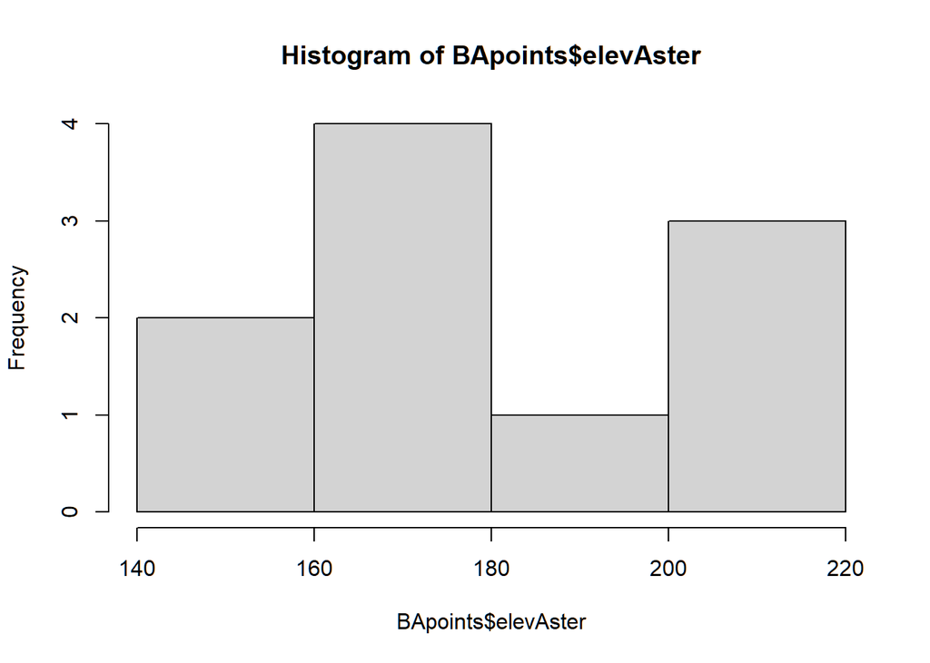

```r
hist(BApoints$elevAster)
```

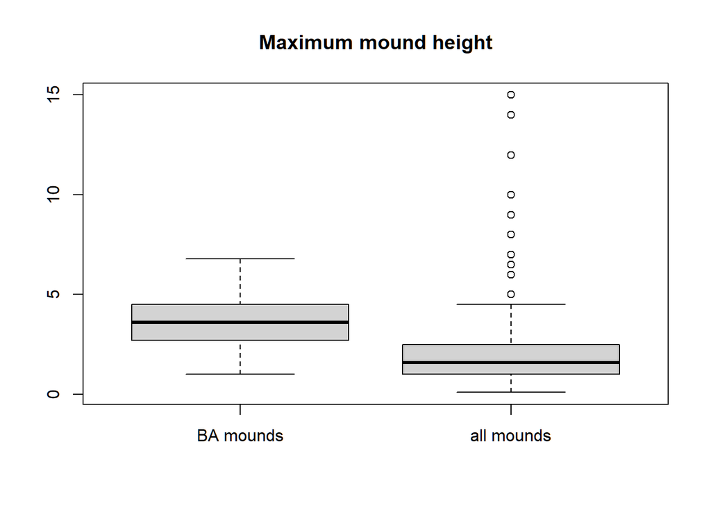

```r
boxplot(BApoints$HeightMax[BApoints$HeightMax>0], Yam_mnds$HeightMax[Yam_mnds$HeightMax>0], names = c("BA mounds", "all mounds"), main = "Maximum mound height")
```

### Elevations

```r
tiff(filename="../figures/Figure02.tiff", width=600, height=900, units = "mm", res = 300)
Yam_mnds %>%
  ggplot() +
  geom_histogram(aes(x=elevAster,  fill = "All"), binwidth = 10)  +
  geom_histogram(data = BApoints, aes(x=elevAster,  fill = "Bronze Age"),  binwidth = 10) +
  labs(title = "Mound elevations in Yambol",
       x = "Elevation (m)",
       y = "Count")+
  theme_bw(base_size=60)+
  scale_fill_grey( name = "Mounds") +
  theme(legend.position = "bottom")
        #legend.text = element_text(size=48),
        #axis.text=element_text(size=48),
        #axis.title=element_text(size=48,face="bold"))
dev.off()#
```

### Prominence comparison

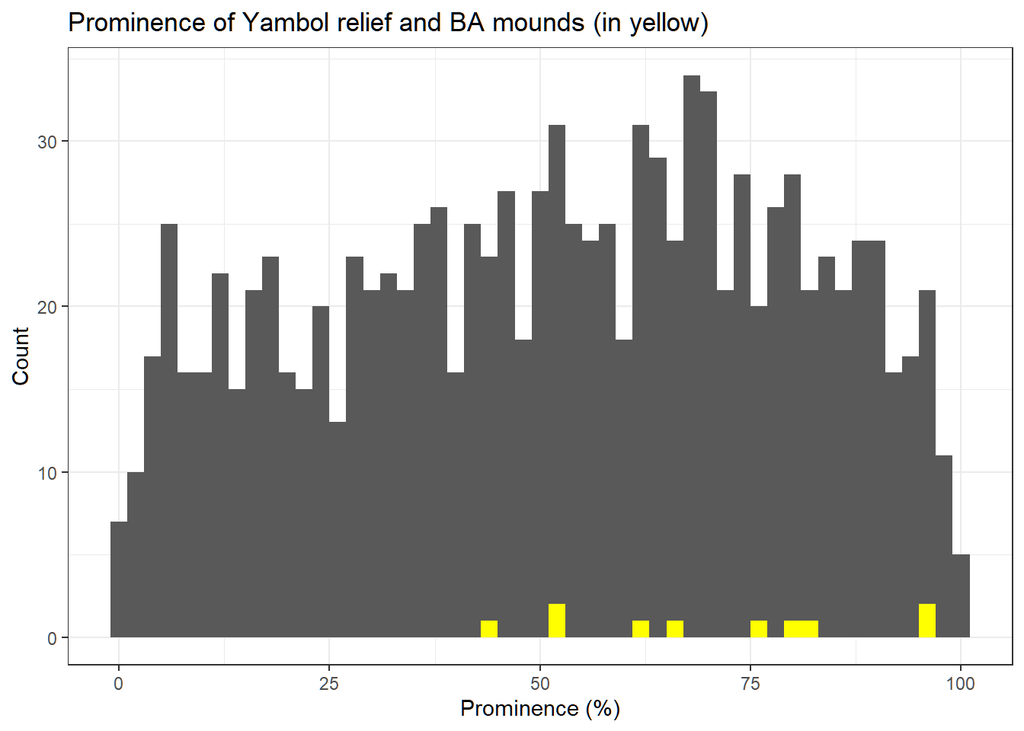

```r
Yam_mnds %>%
  ggplot() +
  geom_histogram(aes(x=prom250mbuff), binwidth = 2)  +
  geom_histogram(data = BApoints, aes(x=prom250mbuff), fill = "yellow", binwidth = 2) +
  labs(title = "Prominence of Yambol relief and BA mounds (in yellow)",
       x = "Prominence (%)",
       y = "Count")+
  theme_bw()
```

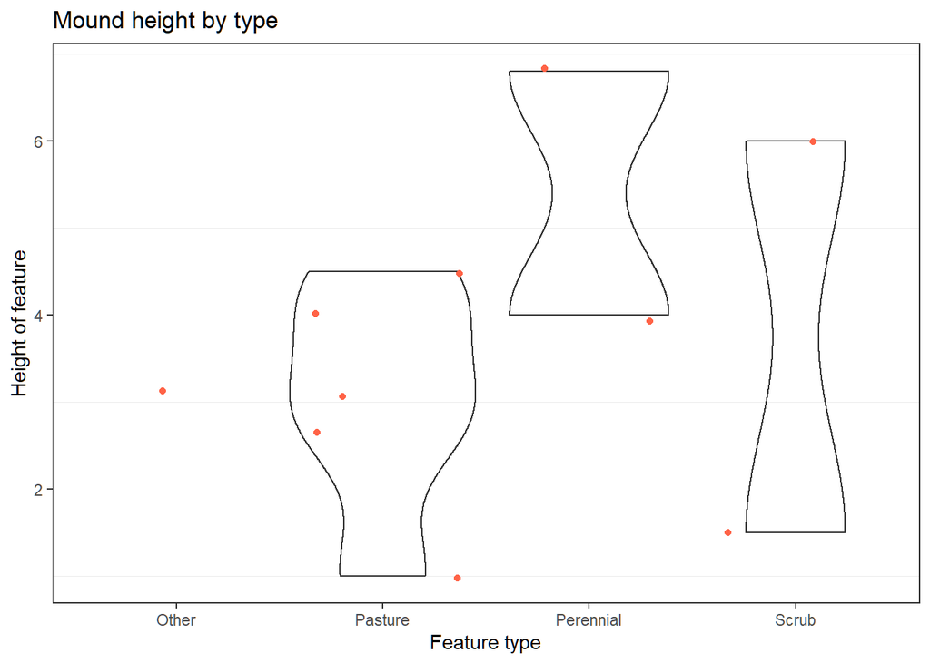

```r
BApoints %>%
  ggplot(aes(x = LU_Around, y = HeightMax)) +
  geom_violin(alpha = 0)+
  geom_jitter(color = "tomato")+
  theme_bw()+
  theme(panel.grid.major = element_blank())+
  labs(x = "Feature type",
       y = "Height of feature",
       title = "Mound height by type")
```

### Prominence densities

To get prominence plotted as densities rather than histograms, one must rerun ProminenceMC script.

```r
# Calculate the mound densities

library(foreach)
library(purrrlyr)

#note the exposition pipe operator $, which works as dataframe$variable
BAmounds_densities <- BApoints %$%
  prom250mbuff %>%
  density(from = 0,
            to = 100,
            n = 1201) %>%
   broom::tidy() %>%
   tibble::as_tibble() %>%
  dplyr::mutate(y = y * 1201) %>%
  dplyr::rename(Prominence = x,
                Frequency = y)

ggplot() +
  geom_line(data = yambol_region_densities,
            mapping = aes(x = Prominence,
                          y = Frequency),
            col = "lightgrey") +
  geom_ribbon(data = yambol_densities_wide,
              mapping = aes(x = Prominence,
                            ymin = `Lower CI`,
                            ymax = `Upper CI`),
              col = "darkgrey",
              alpha = 0.5) +
  geom_line(data = mounds_densities,
               mapping = aes(x = Prominence,
                             y = Frequency),
               color = "red", size = 2)+
  geom_line(data = BAmounds_densities,
               mapping = aes(x = Prominence,
                             y = Frequency),
               color = "pink", size = 2)+
  theme_bw()+
  labs(x = "Topographic Prominence (%)")
```